# Iran Human Rights

Mehr Qayyum

2026-01-14

# Background

“Iran’s binding obligations under international human rights law, including the International Covenant on Civil and Political Rights (ICCPR). Peaceful protest is not a security threat; it is a protected civic right. The systematic suppression of dissent—through lethal force, mass arrests, and communication blackouts— risks further loss of life and irreversible damage to the rule of law.

The National Iranian American Council strongly condemns the killing of peaceful protesters, including children, and stands in solidarity with the Iranian people against this brutal crackdown.” ~National Iranian American Council

Works fine because the table is small and not sparse

Class Notes: * Compare 2 affiliations on 1 violation type = Use Two‑proportion test * Compare 2 affiliations on all violation types = Use Small chi‑square * Compare all 43 affiliations on 1 violation type = Use Logistic regression * Compare all 43 affiliations on all violation types = Use Multinomial or log‑linear model * BUT Run 903 pairwise comparisons =Possible but not recommended BUT, If we compare all 43 affiliations simultaneously across all violation types

That’s a 43 × 21 chi‑square test, but it fails because:

too many cells and too many zeros

expected counts < 5 everywhere

df = 840

chi‑square approximation breaks

So the global chi‑square is not reliable.

```r
#Load libraries and read data
library(tidyverse)
library(broom)

iran_df <- read.csv("/Users/mehrunisaqayyum/Desktop/CAIR_JVP_Action/Iran_HRANA_human_rights.csv")
iran_df
```

| ID | Type | Name | Affiliation | Violation_Type | X | X.1 |
| --- | --- | --- | --- | --- | --- | --- |
| sj75421 | Individual | Fathollah Jomeyri | Islamic Revolutionary Guard Corps (IRGC) | Freedom of expression and thought \|Children's rights \|Death of civilians \|Right to Protest \|Social rights \|Use of Excessive Force on Civilians \| |  |  |
| sj78170 | Individual | Alireza Noshad | Law Enforcement Force | Freedom of expression and thought \|Children's rights \|Death of civilians \|Right to Protest \|Social rights \|Use of Excessive Force on Civilians \| |  |  |
| sj33897 | Individual | Masoud Tahmasebi | Government of Islamic Republic of Iran | Freedom of expression and thought \|Death of civilians \|Religious minorities \|Right to Protest \|Social rights \|Use of Excessive Force on Civilians \| |  |  |
| sj49869 | Individual | Mohammad-Reza Mirheidari | Law Enforcement Force | Freedom of expression and thought \|Right to Freedom \|Right to Protest \|Social rights \| |  |  |
| sj59534 | Individual | Gholamreza Shabaninia | Islamic Revolutionary Guard Corps (IRGC) | Freedom of expression and thought \|Right to Protest \|Social rights \|Death of civilians \|Use of Excessive Force on Civilians \| |  |  |
| sj46001 | Individual | Ali-Akbar Jahed | Government of Islamic Republic of Iran | Freedom of expression and thought \|Children's rights \|Death of civilians \|Right to Protest \|Social rights \|Use of Excessive Force on Civilians \| |  |  |
| sj45288 | Individual | Morteza Sheykhi | Islamic Revolutionary Guard Corps (IRGC) | Freedom of expression and thought \|Children's rights \|Death of civilians \|Right to Protest \|Social rights \|Use of Excessive Force on Civilians \|The right to life \| |  |  |
| sj11410 | Individual | Amin Pourahmadian | Law Enforcement Force | Freedom of expression and thought \|Children's rights \|Death of civilians \|Right to Protest \|Social rights \|Use of Excessive Force on Civilians \| |  |  |
| sj33596 | Individual | Edris Abdi | Judicial system of Iran | Prisoner's rights \|Children's rights \|LGBTQ+ rights \|Social rights \|Torture \|Use of Excessive Force on Civilians \|Women's rights \| |  |  |
| sj31098 | Individual | Abbas Ghaderi | Judicial system of Iran | LGBTQ+ rights \| |  |  |

[output cut: 937 more lines]

```r
head(iran_df)
```

|  | ID | Type | Name | Affiliation | Violation_Type | X | X.1 |
| --- | --- | --- | --- | --- | --- | --- | --- |
| 1 | sj75421 | Individual | Fathollah Jomeyri | Islamic Revolutionary Guard Corps (IRGC) | Freedom of expression and thought \|Children's rights \|Death of civilians \|Right to Protest \|Social rights \|Use of Excessive Force on Civilians \| |  |  |
| 2 | sj78170 | Individual | Alireza Noshad | Law Enforcement Force | Freedom of expression and thought \|Children's rights \|Death of civilians \|Right to Protest \|Social rights \|Use of Excessive Force on Civilians \| |  |  |
| 3 | sj33897 | Individual | Masoud Tahmasebi | Government of Islamic Republic of Iran | Freedom of expression and thought \|Death of civilians \|Religious minorities \|Right to Protest \|Social rights \|Use of Excessive Force on Civilians \| |  |  |
| 4 | sj49869 | Individual | Mohammad-Reza Mirheidari | Law Enforcement Force | Freedom of expression and thought \|Right to Freedom \|Right to Protest \|Social rights \| |  |  |
| 5 | sj59534 | Individual | Gholamreza Shabaninia | Islamic Revolutionary Guard Corps (IRGC) | Freedom of expression and thought \|Right to Protest \|Social rights \|Death of civilians \|Use of Excessive Force on Civilians \| |  |  |
| 6 | sj46001 | Individual | Ali-Akbar Jahed | Government of Islamic Republic of Iran | Freedom of expression and thought \|Children's rights \|Death of civilians \|Right to Protest \|Social rights \|Use of Excessive Force on Civilians \| |  |  |

```r
summary(iran_df) #
```

```
##       ID                Type               Name           Affiliation
##  Length:947         Length:947         Length:947         Length:947
##  Class :character   Class :character   Class :character   Class :character
##  Mode  :character   Mode  :character   Mode  :character   Mode  :character
##  Violation_Type          X                 X.1
##  Length:947         Length:947         Length:947
##  Class :character   Class :character   Class :character
##  Mode  :character   Mode  :character   Mode  :character
```

#Clean: treat each row as a pipe‑separated list of violation types, split them into individual entries, clean them, and #then count how often each one appears across all 947 records.

```r
#Count Human Rights Violation Type

#split on pipe |
iran_df_long <- iran_df %>%
  separate_rows(Violation_Type, sep = "\\|")

#Clean white space
iran_df_long  <- iran_df_long  %>%
  mutate(Violation_Type = str_trim(Violation_Type)) %>%
  filter(Violation_Type != "")

#Count Each violation type
violation_counts <- iran_df_long %>% count(Violation_Type, sort = TRUE)
violation_counts
```

| Violation_Type | n |
| --- | --- |
| Freedom of expression and thought | 709 |
| Social rights | 633 |
| Right to Protest | 591 |
| The right to life | 418 |
| Right to Freedom | 409 |
| Women's rights | 338 |
| Death of civilians | 302 |
| Use of Excessive Force on Civilians | 299 |
| Prisoner's rights | 229 |
| Religious minorities | 215 |

[output cut: 11 more lines]

```r
#Subset to list of 10
top_10 <- violation_counts %>% slice_max(n, n = 10)

#Flag top 10 in main data frame
iran_df_long <- iran_df_long %>% mutate(is_top_10 = Violation_Type %in% top_10$Violation_Type)
```

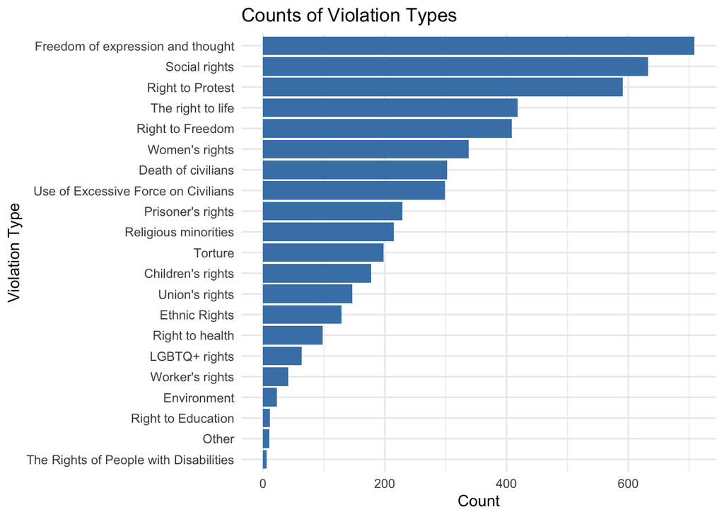

```r
#Visualize All Types in Horizontal
ggplot(violation_counts, aes(x = reorder(Violation_Type, n), y = n)) + geom_col(fill = "steelblue") + coord_flip() + labs( title = "Counts of Violation Types", x = "Violation Type", y = "Count" ) + theme_minimal()
```